# 马尔可夫链蒙特卡罗（MCMC）方法及其应用

为了补偿“指数爆炸”现象，我们考虑构造建议分布$g(\cdot|X)$，该密度函数认为$X$点左侧为均匀分布，右侧为指数分布，直观上看就是从X点水平向左砍，将砍下来的部分补在右边，如图是$g(\cdot|1)$的图像与$e^x$的对比

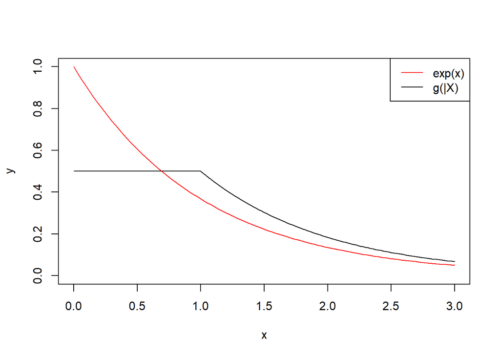

将上述建议分布做成样本生成器`mtrp_expu`，并使用其生成10000个样本

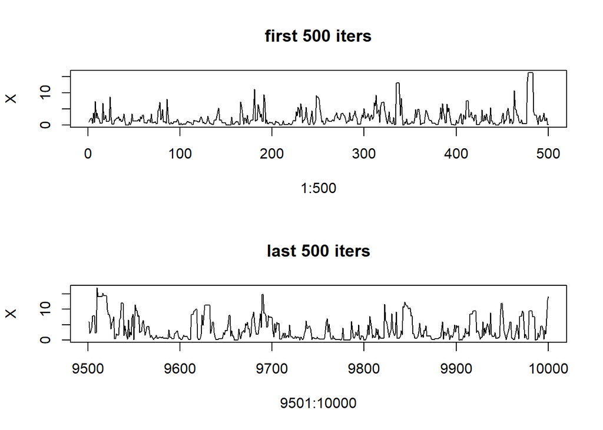

```r
# generating random variates using function `mtrp_expu`
set.seed(1234)
x.pareto <- mtrp_expu(f, 10000, 1, rate = 0.5, burn = 0)
cat("The sample rejection rate is", x.pareto$alpha, "\n")
## The sample rejection rate is 0.2326
par(mfrow = c(2, 1))
plot(1:500, x.pareto$chain[1:500], type = "l",
     main = "first 500 iters", ylab = "X")
plot(9501:10000, x.pareto$chain[9501:10000], type = "l",
     main = "last 500 iters", ylab = "X")
```

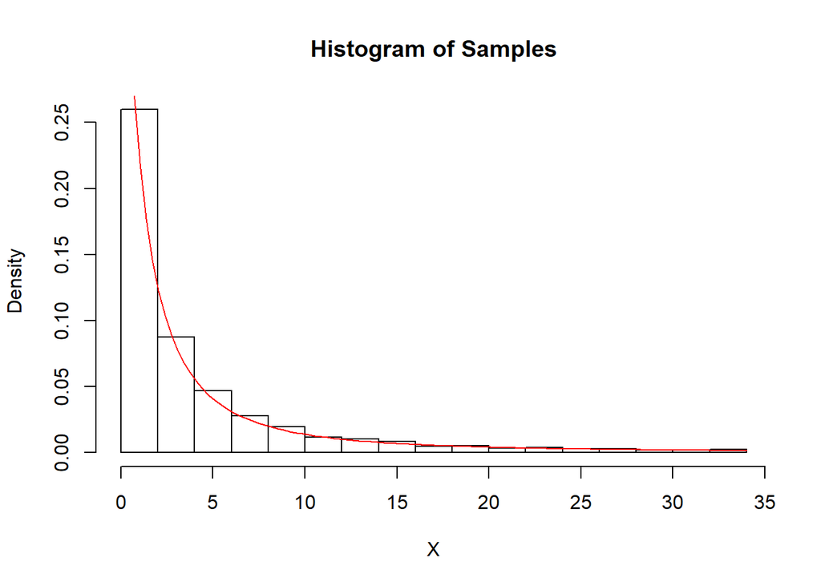

```r
par(mfrow = c(1, 1))
hist(x.pareto$chain, freq = FALSE, main = "Histogram of Samples", xlab = "X")
curve(r * beta^r * (x + beta)^(-(r+1)), from = 0, col = "red", add = TRUE)
```

观察上图可以看出，使用函数`mtrp_expu`生成的样本与理论分布相符合的较好，因此`mtrp_expu`可以作为情形2对于指数分布的一个有力替代者

# 5 Gibbs样本生成器

Gibbs样本生成器实际上可以看成Metropolis-Hastings样本生成器的一种特殊情况，当目标函数为多元分布时经常使用Gibbs样本生成器。假设所有的一元条件密度是完全指定的，并且从中抽样相当简单，链条是从目标分布的边缘分布抽样生成的，且因此每一个候选点都被接受了。

令$\mathbf{X}=(X_1,\dots,X_d)$是$\mathbb{R}^d$中的随机向量，定义$d-1$维向量
$$\mathbf{X}_{(-j)}=(X_1,\dots,X_{j-1},X_{j+1},\dots,X_d)$$
用$f(X_j|\mathbf{X}_{(-j)})$表示给定$\mathbf{X}_{(-j)}$时$X_j$对应的一元条件分布。Gibbs样本生成器通过从每一个条件密度$f(X_j|\mathbf{X}_{(-j)})$抽样生成链条。

将Gibbs样本生成器的步骤概括如下：

1. 在时间$t=0$初始化$\mathbf{X}_0$；
2. 每次迭代（标记为$t=1,2,\dots$）重复下面过程有限（n）次：
   1. 记当前状态$\mathbf{X}_t=(X_1,X_2,\dots.X_d)$；
   2. 从坐标$\{1,2,\dots,d\}$中抽取一个数，不妨记为$j$；
   3. 从$f(X_j|\mathbf{X}_{(-j)})$生成y
   4. 令$\mathbf{X}_{t+1}=(X_1,\dots,X_{j-1},y,X_{j+1},\dots,X_d)$
   5. 增加t

需要证明在循环中使用的建议分布的接受率满足

$$\alpha(X_t,Y)=\min\{1,\frac{f(Y)g(X_t|Y)}{f(X_t)g(Y|X_t)}\}=1$$

实际上

$$\frac{f(Y)g(X_t|Y)}{f(X_t)g(Y|X_t)}=\frac{f(Y)}{f(X_t)}\frac{1}{d}\frac{f(X_t)}{P(X_{-j})}(\frac{1}{d}\frac{f(Y)}{P(X_{-j})})^{-1}=1$$

其中假设当前状态为$X_t$时，下一状态更新的坐标为$j$，$P(X_{-j})$表示$(X_1,\dots,X_{j-1},X_{j+1},\dots,X_d)$的联合分布。由此，证明了Gibbs样本生成器是一种特殊的Metropolis-Hastings算法，它的接受率为1，即每次都发生状态转移，因此在多维的情形效率较传统的Matropolis-Hastings样本生成器效率显著提高。

## 5.1 多元正态分布

多元正态分布是典型的Gibbs使用场合，假设$\mathbf{X}=(X_1,X_2,\dots,X_d)\sim \mathrm{N}(\mu,\Sigma)$，则$f(X_j|\mathbf{X}_{-j})=\mu_j+\Sigma_{j,-j}\Sigma_{-j,-j}(\mathbf{X}_{-j}\mu_{-j})$，其中$\Sigma_{j,-j}$为$\Sigma$第$j$行，去掉第$j$列的余子式，$\Sigma_{-j,-j}$为$\Sigma$去掉第$j$行，第$j$列的余子式。

于是，Gibbs-Normal样本生成器的步骤概括如下：

假设样本为$d$维向量，产生$n$个样本

1. 在时间$t=0$初始化$\mathbf{X}_0$；
2. 每次迭代（标记为$t=1,2,\dots$）重复下面过程有限（n）次：
   1. 记当前状态$\mathbf{X}_t=(x_1,x_2,\dots.x_d)$；
   2. 从坐标$\{1,2,\dots,d\}$中抽取一个数，不妨记为$j$；
   3. 从$X_j|\mathbf{X}_{-j}\sim \mathrm{N}(\mu_j+\Sigma_{j,-j}\Sigma_{-j,-j}^{-1}(\mathbf{X}_{-j}-\mu_{-j}),\Sigma_{j,j}-\Sigma_{j,-j}\Sigma_{-j,-j}^{-1}\Sigma_{-j,j})$生成$X_j$
   4. 令$\mathbf{X}_{t+1}=(x_1,\dots,x_{j-1},X_j,x_{j+1},\dots,x_d)$
   5. 增加t
3. 如果设置burn，舍去前burn个样本; 返回$n\times d$的矩阵，每一行为一个样本

通过上述算法编写了函数`gibbs_norm`，可以用Gibbs样本生成器生成任意维任意参数的服从正态分布的样本

```r
# provide some parameters
mu <- c(1,3)
A <- matrix(c(1, 0.1, 0.1, 1), nrow = 2)
```

通过函数`gibbs_norm`产生10000个样本

```r
# generating random variates
set.seed(1234)
x.norm <- gbs_norm(10000, mu, A, mu, burn = 0)
cat("The sample mean is", colMeans(x.norm), "\n")
## The sample mean is 0.9963282 3.022157
cat("The sample covariance matrix is\n")
## The sample covariance matrix is
cov(x.norm)
```

```
##          [,1]     [,2]
## [1,] 1.020903 0.106353
## [2,] 0.106353 0.939146
```

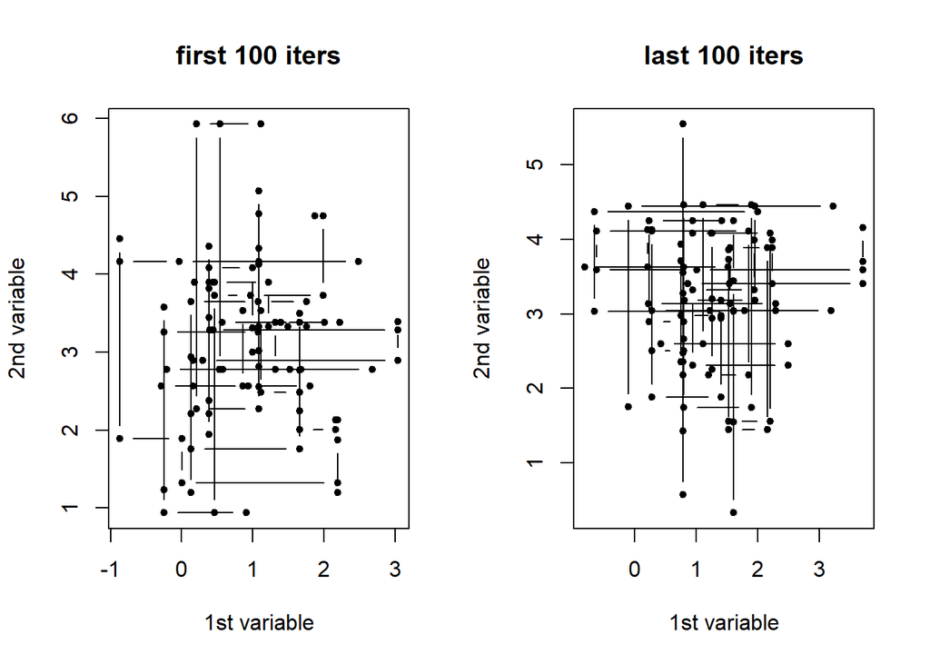

```r
par(mfrow = c(1, 2))
plot(x.norm[1:100, 1], x.norm[1:100, 2], type = "b", pch = 20,
     main = "first 100 iters", xlab = "1st variable", ylab = "2nd variable")
plot(x.norm[9901:10000, 1], x.norm[9901:10000, 2], type = "b",
     pch = 20, main = "last 100 iters", xlab = "1st variable", ylab = "2nd variable")
```

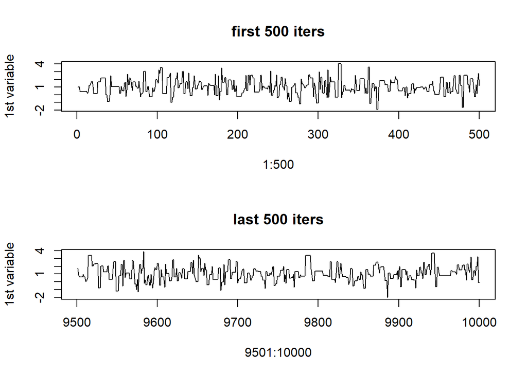

```r
par(mfrow = c(2, 1))
plot(1:500, x.norm[1:500, 1], type = "l", ylab = "1st variable",
     main = "first 500 iters")
plot(9501:10000, x.norm[9501:10000, 1], type = "l", ylab = "1st variable",
     main = "last 500 iters")
```

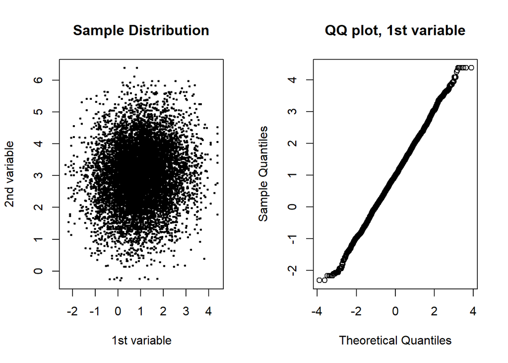

```r
par(mfrow = c(1, 2))
plot(x.norm, pch = 20, cex = 0.5, main = "Sample Distribution",
     xlab = "1st variable", ylab = "2nd variable")
qqnorm(x.norm[, 1], main = "QQ plot, 1st variable")
```

```r
par(mfrow = c(1, 1))
```

可以看到二维Markov链时间图中每时刻状态的转移总与某一坐标轴平行，且一维Markov链时间图中每个分类大约有一半的时间不更新，看起来效率不高，实际上，状态每时每刻都在发生改变，该样本生成器的拒绝率为0，效率最高。与标准正态分布对比，发现在中间部分吻合地极好。

## 5.2 Metropolis-Hastings样本生成器与Gibbs样本生成器的对比

```r
# getting `x.norm` and `x.gbs`
set.seed(123)
mu <- c(1,3)
A <- matrix(c(1, 0.1, 0.1, 1), nrow = 2)
A.inv <- solve(A)
f <- function(x) {
  stopifnot(length(x) == length(mu))
  return(as.vector(exp(-0.5 * t(x - mu) %*% A.inv %*% (x - mu))))
}
x.mtrp <- mtrp(f, 10000, mu)
x.gbs <- gbs_norm(10000, mu, A, mu)
```

```r
cat("Metropolis-Hastings:\n")
## Metropolis-Hastings:
cat("Mean:", colMeans(x.mtrp$chain), "\n")
## Mean: 0.9978013 2.988197
cat("Covariance matrix:\n")
## Covariance matrix:
cov(x.mtrp$chain)
```

```
##           [,1]      [,2]
## [1,] 0.9961111 0.0623746
## [2,] 0.0623746 1.0593604
```

```r
cat("\nGibbs:\n")
```

```
##
## Gibbs:
```

```r
cat("Mean:", colMeans(x.gbs), "\n")
## Mean: 1.005483 2.997672
cat("Covariance matrix:\n")
## Covariance matrix:
cov(x.gbs)
```

```
##           [,1]      [,2]
## [1,] 0.9986702 0.1029445
## [2,] 0.1029445 1.0070461
```

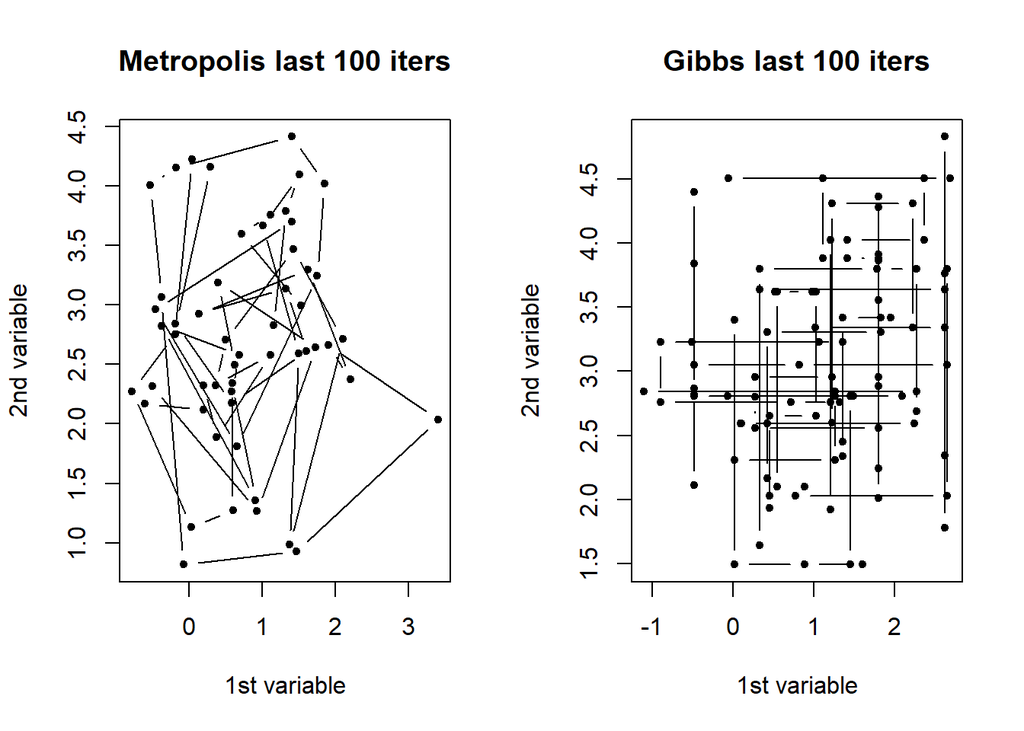

```r
par(mfrow = c(1, 2))
plot(x.mtrp$chain[9901:10000, 1], x.mtrp$chain[9901:10000, 2], type = "b",
     pch = 20, main = "Metropolis last 100 iters",
     xlab = "1st variable", ylab = "2nd variable")
plot(x.gbs[9901:10000, 1], x.gbs[9901:10000, 2], type = "b",
     pch = 20, main = "Gibbs last 100 iters",
     xlab = "1st variable", ylab = "2nd variable")
```

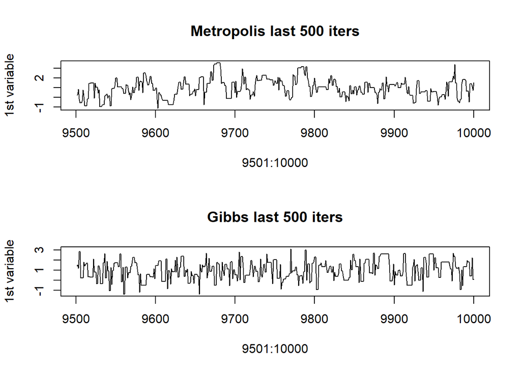

```r
par(mfrow = c(2, 1))
plot(9501:10000, x.mtrp$chain[9501:10000, 1], type = "l", ylab = "1st variable",
     main = "Metropolis last 500 iters")
plot(9501:10000, x.gbs[9501:10000, 1], type = "l", ylab = "1st variable",
     main = "Gibbs last 500 iters")
```

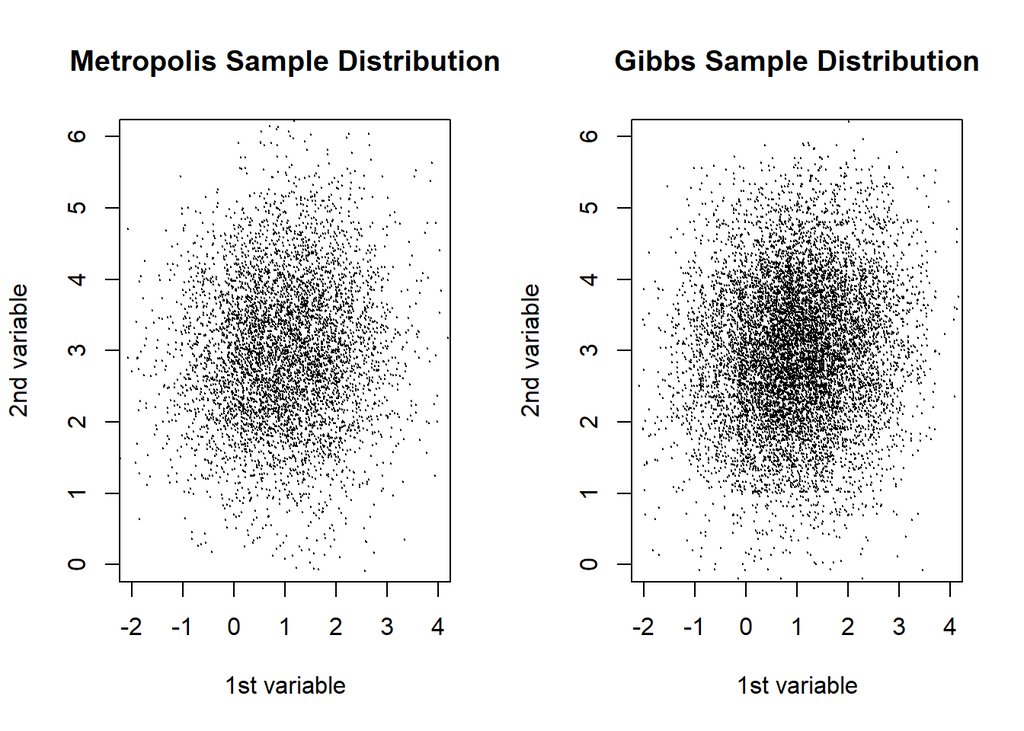

```r
par(mfrow = c(1, 2))
plot(x.mtrp$chain, cex = 0.1, pch = 20,
     xlim = c(-2, 4), ylim = c(0, 6),
     xlab = "1st variable", ylab = "2nd variable",
     main = "Metropolis Sample Distribution")
plot(x.gbs, cex = 0.1, pch = 20,
     xlim = c(-2, 4), ylim = c(0, 6),
     xlab = "1st variable", ylab = "2nd variable",
     main = "Gibbs Sample Distribution")
```

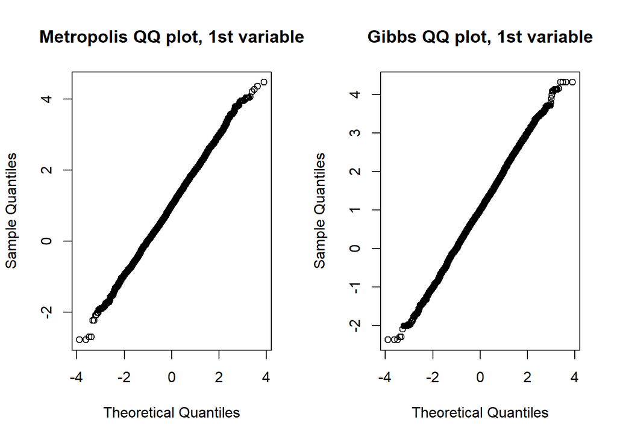

```r
qqnorm(x.mtrp$chain[, 1], main = "Metropolis QQ plot, 1st variable")
qqnorm(x.gbs[, 1], main = "Gibbs QQ plot, 1st variable")
```

```r
par(mfrow = c(1, 1))
```

均值二者相近，且均接近理论值，但$X$和$Y$的协方差项Gibbs样本生成器表现得很好，为0.103接近理论值0.1，而Metropolis-Hastings样本生成器的结果是0.062，有很大的误差。观察二维的Markov链转移图，发现Gibbs样本生成器最终的状态比Metropolis-Hastings更稳定，不倾向于产生较多的离群值。观察$X$的Markov链转移图，发现尽管Gibbs样本生成器在$X$分量上拒绝率为0.5，但相比于Metropolis，出现长横线（较长时间内连续被拒绝）的概率要低得多。在样本分布图中可以看出Gibbs样本点的数量更多，且更加均匀。对比理论分布做出QQ图，可以看出二者均与理论分布符合的较好，但Metropolis-Hastings样本生成器产生了为数不多的离群值（左图左下角看出）。

因此，Gibbs样本生成器比Metropolis-Hastings样本生成器在产生多元正态分布上表现更好。

## 5.3 多项分布

要产生参数为$(N, \mathbf{p})$的$n$项分布，其中$N$是独立重复实验次数，$\mathbf{p}=(p_1,\dots.p_n)$是$n$维概率值向量，可以依次对每个坐标分量产生二项分布，并且有
$$X_j|(X_1,\dots,X_{j-1})\sim \mathrm{B}(N-\sum_{k=1}^{j-1}X_k,\frac{p_j}{\sum_{k=j}^{n}p_k}))$$
采用这种算法，产生$10000$个服从$(1000,\mathbf{p})$的样本，需要产生$10000\times1000=10^7$个二项分布数。而通过Gibbs样本生成器的方法，可以大大提高产生多项分布数的效率，若使用下面介绍的算法，假设燃烧期为$1000$，则仅需产生$10000+1000=1.1\times10^4$个二项分布数，时间前者是后者的$1000$倍

假设t时刻状态为$\mathbf{X_t}=(x_1,\dots,x_d)$，下一时刻随机选取两个坐标，不妨设为$(i,j)$，将$\mathbf{X_t}$去掉$(X_i,X_j)$的$d-2$维向量记为$\mathbf{X}_{-i,-j}=(x_1,\dots,x_{i-1},x_{i+1},\dots,x_{j-1},x_{j+1},\dots,x_d)$，则此时固定$\mathbf{X}_{-i,-j}$，将$i,j$坐标视为随机变量，考虑条件分布即$(X_i,X_j)|\mathbf{X}_{-i,-j}$，由于多项分布试验次数固定，此时满足$X_i+X_j=N-\sum_{k=1,k\ne i,j}^{d}x_k$记为$s$，即$X_i+X_j=s$，且
$$X_i\sim\mathrm{B}(s,\frac{p_i}{p_i+p_j})$$
，即$(X_i,X_j)|\mathbf{X}_{-i,-j}$服从一个二项分布，因此可以使用Gibbs样本生成器。

Gibbs-Multinom样本生成器的步骤：

假设样本为$d$维向量，产生$n$个样本

1. 在时间$t=0$初始化$\mathbf{X}_0$；
2. 每次迭代（标记为$t=1,2,\dots$）重复下面过程有限（n）次：
   1. 记当前状态$\mathbf{X}_t=(x_1,x_2,\dots.x_d)$；
   2. 从坐标$\{1,2,\dots,d\}$中抽取两个数，不妨记为$i,j$；
   3. 记$s=X_i+X_j$
   4. 从$X_i\sim\mathrm{B}(s,\frac{p_i}{p_i+p_j})$生成$X_i$
   5. 令$X_j=s-X_i$得到$X_j$
   6. 令$\mathbf{X}_{t+1}=(x_1,\dots,x_{i-1},X_i,x_{i+1},\dots,x_{j-1},X_j,x_{j+1},\dots,x_d)$
   7. 增加t
3. 如果设置burn，舍去前burn个样本; 返回$n\times d$的矩阵，每一行为一个样本

通过上述算法编写了函数`gibbs_multinom`，可以用Gibbs样本生成器生成任意维任意参数的服从多项分布的样本

设置多项分布的参数(N, p) = (size, prob)

```r
# setting some parameters
set.seed(123)
prob <- c(0.2, 0.1, 0.1, 0.1, 0.1, 0.1,
          0.05, 0.05, 0.05, 0.05, 0.02, 0.02, 0.02, 0.02, 0.02)
p <- sample(prob)
```

使用函数`gbs_multinom`在不同$N$的情况分别产生10000个样本，观察第1个分量的Markov链转移情况以及直方图

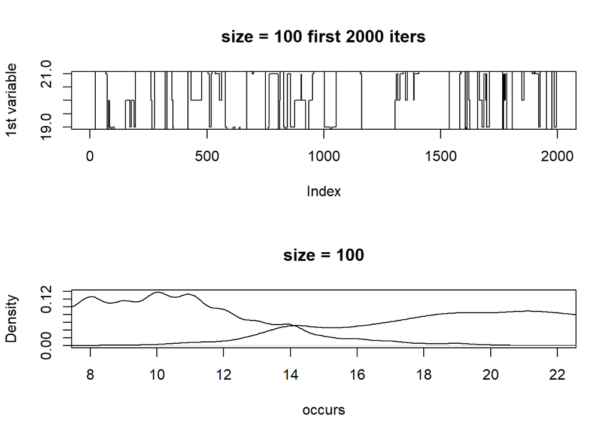

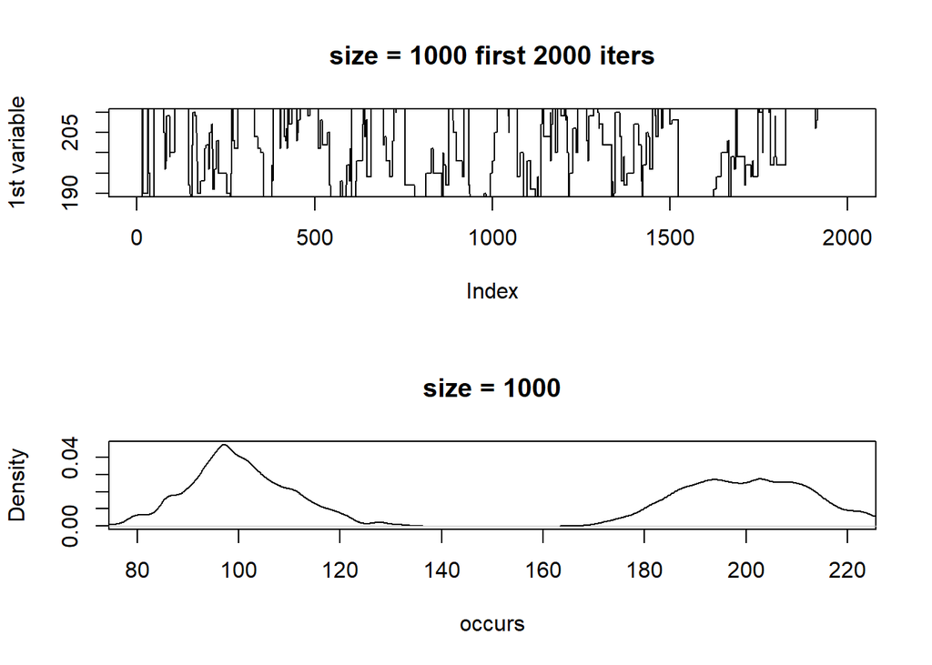

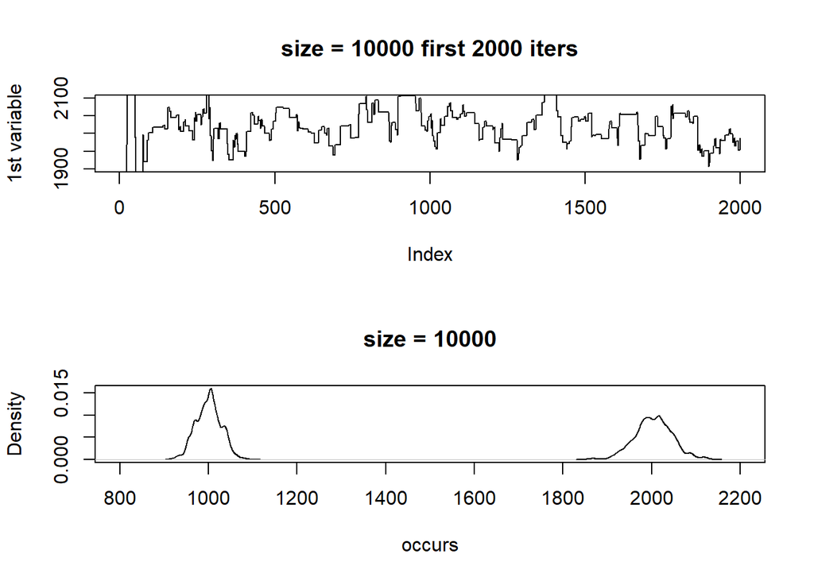

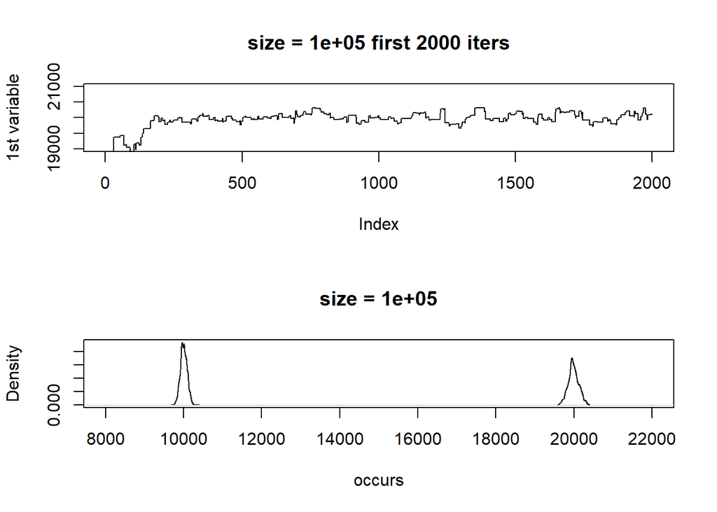

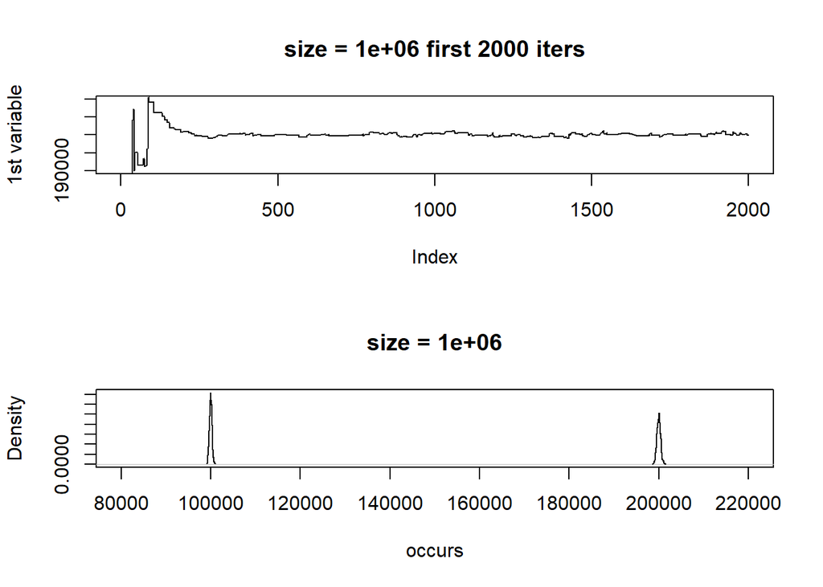

```r
# generating random varaites
set.seed(1234)
par(mfrow = c(2, 1))
for (size in 10^(2:6)) {
  init <- size * p
  x.multinom <- gbs_multinom(10000, size, prob, init, burn = 0)
  plot(x.multinom[1:2000, 1], type = "l", ylab = "1st variable",
       ylim=c(0.95*0.2*size, 1.05*0.2*size),
       main = paste("size =", size, "first 2000 iters"))
  plot(density(x.multinom[-(1:1000), 2]), xlab = "occurs",
       xlim = c(0.08*size, 0.22*size),
       main = paste("size =", size))
  lines(density(x.multinom[-(1:1000), 1]))
}
```

```r
par(mfrow = c(1, 1))
```

上图是第1个分量的Markov链转移图和第1，2个分量的核密度函数估计图，坐标轴单位均与试验次数$N$成正比。可以看到，随着N的增大，Gibbs样本生成器产生的Markov链越来越稳定，样本的方差越来越小，所得结果越来越准确。特别地，当$N=100$很小时，样本的分布看不出规律，可以看出此时的Markov链是不收敛或收敛速度很慢的。

# 6 `mcmcn`包的介绍

已经将上文中使用的用MCMC方法产生随机数的函数`mtrp`、`mtrp_exp`、`mtrp_unif`、`mtrp_expu`、`gibbs_norm`和`gbs_multinom`打包存入`mcmcn`包中，下面分别阐述每个函数的算法和源代码。

## 6.1 `mtrp`

用MCMC方法产生服从任意分布的样本，采用随机游走Metropolis样本生成器，使用正态分布做建议函数。

### 6.1.1 算法

Usage: mtrp(f, n, init, stepsize = 1, burn = 1000)

1. 通过传入参数获得目标分布$f(x)=$`f`，产生的样本数$n=$`n`，初始值`init`（向量），正态分布密度函数的标准差`stepsize`（向量）默认值为1，燃烧期`burn`默认值为1000
2. 检查异常情况：如密度函数无限，燃烧期为负值等等
3. 根据传入值创建局部变量样本维数$d=$`nvar <- length(init)`，迭代次数`iters <- n + burn`，样本存储矩阵`chain <- matrix(0, iters, nvar)`
4. 令 `chain[1, ] <- init`，`k <- 0`
5. 迭代`iters-1`次`for (i in 2:iters)`
   1. 从标准正态分布中抽取$n$个随机数，令候选点`y <- chain[i - 1, ] + rnorm(nvar) * stepsize`，即
      $$Y\sim \mathrm{N}(\text{chain[i - 1, ]},\text{diag(stepsize)})$$
   2. 重复循环

      ```r
      while (f(y) < 1e-16) {
            y <- chain[i - 1, ] + rnorm(nvar) * stepsize
          }
      ```

      直到满足`f(y) >= 1e-16`的条件，即此时`y`位于$f(x)$支集内
   3. 判断是否更新

      若满足`f(y) >= runif(1) * f(chain[i - 1, ])`，即
      $$U\le\frac{f(Y)}{f(X_t)}$$
      令`chain[i, ] <- y`，即接受`y`；

      否则`k <- k + 1`，`chain[i, ] <- chain[i - 1, ]`，状态维持，计数器`k`自增1
6. 返回

   若`burn>=1`返回`list("chain" = chain[-(1:burn), ], "alpha" = k / iters`；

   否则`burn==0`，返回`list("chain" = chain, "alpha" = k / iters`.

### 6.1.2 源代码

```r
mtrp <- function(f,
                 n,
                 init,
                 stepsize = 1,
                 burn = 1000) {
  stopifnot(is.finite(f(init)))
  stopifnot(burn >= 0)

  # number of variates of the distribution
  nvar <- length(init)

  # number of iterations needed to operate
  iters <- n + burn

  # the variates generated in the ith iteration will be stored in chain[i, ],
  # with chain[1, ] storing the initial value
  chain <- matrix(0, iters, nvar)
  chain[1, ] <- init

  # k: counter of rejections
  k <- 0
  for (i in 2:iters) {
    y <- chain[i - 1, ] + rnorm(nvar) * stepsize

    # garantee y is in X
    while (f(y) < 1e-16) {
      y <- chain[i - 1, ] + rnorm(nvar) * stepsize
    }

    # check whether to update
    if (f(y) >= runif(1) * f(chain[i - 1, ])) {
      chain[i, ] <- y
    } else {
      k <- k + 1
      chain[i, ] <- chain[i - 1, ]
    }
  }

  ifelse(burn, return(list(
    "chain" = chain[-(1:burn), ], "alpha" = k / iters
  )), return(list(
    "chain" = chain, "alpha" = k / iters
  )))
}
```

## 6.2 `mtrp_exp`

用MCMC方法产生服从任意分布的样本，采用独立性样本生成器，使用指数分布做建议函数。

### 6.2.1 算法

Usage: mtrp_exp(f, n, init, a = 0, rate = 1, burn = 1000)

与`mtrp`函数基本相同，除了以下几步

1. 通过传入参数获得目标分布$f(x)=$`f`，产生的样本数$n=$`n`，初始值`init`，支撑集的左边界`a`（向量），指数分布的速率`rate`默认值为1，燃烧期`burn`默认值为1000
2. 迭代`iters-1`次`for (i in 2:iters)`
   1. 从标准指数分布中抽取``nvar`个随机数，令候选点`y <- a + rexp(nvar) / rate`，即
      $$Y_i\sim\text{a[i]}+\mathrm{Exp}(\text{rate[i]}),i=1,\dots,d$$
   2. 重复循环
   3. 判断是否更新

   若满足`f(y) * exp(-sum(rate * (chain[i - 1, ] - a))) >= runif(1) * f(chain[i - 1, ]) * exp(-sum(rate * (y - a))))`，即
   $$U\le\frac{f(Y)g(X_t)}{f(X_t)g(Y)}$$
   更新，否则不更新。

### 6.2.2 源代码

```r
mtrp_exp <- function(f,
                     n,
                     init,
                     a = 0,
                     rate = 1,
                     burn = 1000) {
  stopifnot(is.finite(f(init)))
  stopifnot(burn >= 0)

  # number of variates of the distribution
  nvar <- length(init)

  # number of iterations needed to operate
  iters <- n + burn

  # the variates generated in the ith iteration will be stored in chain[i, ],
  # with chain[1, ] storing the initial value
  chain <- matrix(0, iters, nvar)
  chain[1, ] <- init

  # k: counter of rejections
  k <- 0
  for (i in 2:iters) {
    y <- a + rexp(nvar) / rate

    # garantee y is in X
    while (f(y) < 1e-16) {
      y <- a + rexp(nvar) / rate
    }

    # check whether to update
    if (f(y) * exp(-sum(rate * (chain[i - 1, ] - a))) >= runif(1) *
        f(chain[i - 1, ]) * exp(-sum(rate * (y - a)))) {
      chain[i, ] <- y
    } else {
      k <- k + 1
      chain[i, ] <- chain[i - 1, ]
    }
  }

  ifelse(burn, return(list(
    "chain" = chain[-(1:burn), ], "alpha" = k / iters
  )), return(list(
    "chain" = chain, "alpha" = k / iters
  )))
}
```

## 6.3 `mtrp_unif`

用MCMC方法产生服从任意分布的样本，采用独立性样本生成器，使用均匀分布做建议函数。

### 6.3.1 算法

Usage: mtrp_unif(f, n, init, a, b, burn = 1000)

与`mtrp`函数基本相同，除了以下几步

1. 通过传入参数获得目标分布$f(x)=$`f`，产生的样本数$n=$`n`，初始值`init`，支撑集的左边界`a`（向量），支撑集的右边界`b`（向量），燃烧期`burn`默认值为1000
2. 令`sc <- b - a`为缩放倍数，用于对标准均匀分布做变换
3. 迭代`iters-1`次`for (i in 2:iters)`
   1. 从标准均匀分布中抽取`nvar`个随机数，令候选点`y <- a + sc * runif(nvar)`，即
      $$Y_i\sim\text{U}(\text{a[i]},\text{b[i]}),i=1,\dots,d$$
   2. 重复循环
   3. 判断是否更新

   若满足`f(y) >= runif(1) * f(chain[i - 1, ]`，即
   $$U\le\frac{f(Y)}{f(X_t)}$$
   更新，否则不更新。

### 6.3.2 源代码

```r
mtrp_unif <- function(f,
                      n,
                      init,
                      a,
                      b,
                      burn = 1000) {
  stopifnot(is.finite(f(init)))
  stopifnot(burn >= 0)

  # number of variates of the distribution
  nvar <- length(init)

  # number of iterations needed to operate
  iters <- n + burn

  # the variates generated in the ith iteration will be stored in chain[i, ],
  # with chain[1, ] storing the initial value
  chain <- matrix(0, iters, nvar)
  chain[1, ] <- init

  # k: counter of rejections
  k <- 0
  sc <- b - a
  for (i in 2:iters) {
    y <- a + sc * runif(nvar)

    # garantee y is in X
    while (f(y) < 1e-16) {
      y <- a + sc * runif(nvar)
    }

    # check whether to update
    if (f(y) >= runif(1) * f(chain[i - 1, ])) {
      chain[i, ] <- y
    } else {
      k <- k + 1
      chain[i, ] <- chain[i - 1, ]
    }
  }

  ifelse(burn, return(list(
    "chain" = chain[-(1:burn), ], "alpha" = k / iters
  )), return(list(
    "chain" = chain, "alpha" = k / iters
  )))
}
```

## 6.4 `mtrp_expu`

用MCMC方法产生服从任意分布的样本，采用Metropolis-Hastings样本生成器，使用指数和均匀的混合分布做建议函数。

### 6.4.1 算法

mtrp_expu(f, n, init, a = 0, rate = 1, burn = 1000)

与`mtrp_exp`函数基本相同，除了以下几步

5. 迭代`iters-1`次`for (i in 2:iters)`
   1. 从`rexpu`分布中抽取随机数，令候选点`y[j] <- rexpu(1, a[j], x[j], rate[j])`（`rexpu`为`mcmcn`包中所含），即
      $$Y_i\sim\text{Expu}(\text{a[i]},\text{x[i]},\text{rate[i]}),i=1,\dots,d$$
      其中$\text{Expu}(a,x,\lambda)$的pdf为
      $$\begin{cases}
      \frac{1}{x-a+\lambda^{-1}},\quad a\le y\le x\\[6pt]
      \frac{1}{x-a+\lambda^{-1}}e^{-\lambda(y-x)},\quad y>x
      \end{cases}$$
   2. 重复循环
   3. 判断是否更新

   若满足`f(y) * g(x, y) >= runif(1) * f(x) * g(y, x)`，即
   $$U\le\frac{f(Y)g(X_t|Y)}{f(X_t)g(Y|X_t)}$$
   更新，否则不更新。

### 6.4.2 源代码

```r
mtrp_expu <- function(f,
                      n,
                      init,
                      a = 0,
                      rate = 1,
                      burn = 1000) {
  stopifnot(is.finite(f(init)))
  stopifnot(burn >= 0)

  # number of variates of the distribution
  nvar <- length(init)

  # check a and rate
  stopifnot(length(a) == 1 || length(a) == nvar)
  if (length(a) == 1)
    a <- rep(a, nvar)
  stopifnot(length(rate) == 1 || length(rate) == nvar)
  if (length(rate) == 1)
    rate <- rep(rate, nvar)

  # number of iterations needed to operate
  iters <- n + burn

  # the variates generated in the ith iteration will be stored in chain[i, ],
  # with chain[1, ] storing the initial value
  chain <- matrix(0, iters, nvar)
  chain[1, ] <- init

  # k: counter of rejections
  k <- 0

  # generating chain[i, ]
  for (i in 2:iters) {
    x <- chain[i - 1, ]
    y <- numeric(nvar)
    for (j in 1:nvar) {
      y[j] <- rexpu(1, a[j], x[j], rate[j])
    }

    # garantee y is in X
    while (f(y) < 1e-16) {
      for (j in 1:nvar) {
        y[j] <- rexpu(1, a[j], x[j], rate[j])
      }
    }

    # proposal distribution g(y|x)
    g <- function(y, x) {
      return(prod(ifelse(
        y <= x, 1 / (x - a + 1 / rate), exp(-rate * (y - x)) / (x - a + 1 / rate)
      )))
    }

    # check whether to update
    if (f(y) * g(x, y) >= runif(1) * f(x) * g(y, x)) {
      chain[i, ] <- y
    } else {
      k <- k + 1
      chain[i, ] <- x
    }
  }

  ifelse(burn, return(list(
    "chain" = chain[-(1:burn),], "alpha" = k / iters
  )), return(list(
    "chain" = chain, "alpha" = k / iters
  )))
}
```

## 6.5 `gbs_norm`

用MCMC方法产生服从多元正态分布的样本，采用Gibbs样本生成器。

### 6.5.1 算法

Usage: gbs_norm(n, mu, A, init, burn = 1000)

1. 通过传入参数获得生的样本数$n=$`n`，正态分布参数`mu`（向量），`A`（矩阵），初始值`init`（向量），燃烧期`burn`默认值为1000
2. 检查异常情况：如`mu`与`A`不相容，燃烧期为负值等等
3. 根据传入值创建局部变量样本维数$d=$`nvar <- length(init)`，迭代次数`iters <- n + burn`，样本存储矩阵`chain <- matrix(0, iters, nvar)`，`A`的每个对角元余子式的逆`A.inv`是一个$(d-1)\times (d-1)\times d$维的数组`A.inv[, , i] <- solve(A[-i, -i])`，即
   $$\text{A.inv[, , i]}=\text{A[-i, -i]}^{-1}$$
4. 令 `chain[1, ] <- init`，`k <- 0`
5. 迭代`iters-1`次`for (i in 2:iters)`
   1. 在$1,\dots,d$中抽取一个坐标分量`sample(1:nvar, 1)`
   2. 令`chain[i, -j] <- chain[i - 1, -j]`，即$X^{(t+1)}_{-j}=X^{(t)}_{-j}$
   3. 令

      ```r
      chain[i, j] <- rnorm(1, mu[j] + A[j, -j] %*% A.inv[, , j] %*% (chain[i, -j] - mu[-j]),
      (A[j, j] - A[j, -j] %*% A.inv[, , j] %*% A[-j, j]) ^ (1 / 2))
      ```

      即
      $$X_j|\mathbf{X}_{-j}\sim \mathrm{N}(\mu_j+\Sigma_{j,-j}\Sigma_{-j,-j}^{-1}(\mathbf{X}_{-j}-\mu_{-j}),\Sigma_{j,j}-\Sigma_{j,-j}\Sigma_{-j,-j}^{-1}\Sigma_{-j,j})$$
6. 返回

   若`burn>=1`返回`chain[-(1:burn), ]`；否则`burn==0`，返回`chain`.

### 6.5.2 源代码

```r
gbs_norm <- function(n,
                     mu,
                     A,
                     init,
                     burn = 1000) {
  stopifnot(length(mu) == nrow(A) && nrow(A) == ncol(A))
  stopifnot(burn >= 0)

  # number of variates of the distribution
  nvar <- length(mu)

  # Calculate the inverse of A[-i, -i] for i in 1:nvar and store the results in A.inv
  # A.inv will be used for calculating the conditional distribution
  A.inv <- array(0, dim = c(nvar - 1, nvar - 1, nvar))
  for (i in 1:nvar) {
    A.inv[, , i] <- solve(A[-i, -i])
  }

  # number of iterations needed to operate
  iters <- n + burn

  # the variates generated in the ith iteration will be stored in chain[i, ],
  # with chain[1, ] storing the initial value
  chain <- matrix(0, iters, nvar)
  chain[1, ] <- init
  for (i in 2:iters) {
    j <- sample(1:nvar, 1)
    chain[i, -j] <- chain[i - 1, -j]
    chain[i, j] <- rnorm(1,
                         mu[j] + A[j, -j] %*% A.inv[, , j] %*% (chain[i, -j] - mu[-j]),
                         (A[j, j] - A[j, -j] %*% A.inv[, , j] %*% A[-j, j]) ^ (1 / 2))
  }

  ifelse(burn, return(chain[-(1:burn), ]), return(chain))
}
```

## 6.6 `gbs_multinom`

### 6.6.1 算法

Usage: gbs_multinom(n, size, prob, init, burn = 1000)

1. 通过传入参数获得生的样本数$n=$`n`，多项分布参数`size`，`prob`（向量），初始值`init`（向量），燃烧期`burn`默认值为1000
2. 检查异常情况：如`prob`和不为1，`prob`与`init`长度不同，`init`之和与`size`不相同，燃烧期为负值等等
3. 根据传入值创建局部变量样本维数$d=$`nvar <- length(init)`，迭代次数`iters <- n + burn`，样本存储矩阵`chain <- matrix(0, iters, nvar)`
4. 令 `chain[1, ] <- init`，`k <- 0`
5. 迭代`iters-1`次`for (i in 2:iters)`
   1. 在$1,\dots,d$中抽取两个个坐标分量存入`x`，`x <- sample(1:nvar, 2)`，不妨设为$i,j$
   2. 令`s <- sum(chain[i - 1, c(x[1], x[2])])`，即$s=x_i+x_j$
   3. 令`chain[i, -c(x[1], x[2])] <- chain[i - 1, -c(x[1], x[2])]`，即$X^{(t+1)}_{-i,-j}=X^{(t)}_{-i,-j}$
   4. 令`chain[i, x[1]] <- rbinom(1, s, prob[x[1]] / (prob[x[1]] + prob[x[2]]))`， `chain[i, x[2]] <- s - chain[i, x[1]]`，即
      $$X_i\sim\mathrm{B}(s,\frac{p_i}{p_i+p_j})$$
      和
      $$X_j=s-X_i$$
6. 返回

   若`burn>=1`返回`chain[-(1:burn), ]`；否则`burn==0`，返回`chain`.

### 6.6.2 源代码

```r
gbs_multinom <- function(n,
                      size,
                      prob,
                      init,
                      burn = 1000) {
  stopifnot(sum(prob) == 1)
  stopifnot(length(prob) == length(init))
  stopifnot(sum(init) == size)
  stopifnot(burn >= 0)

  # number of variates of the distribution
  nvar <- length(prob)

  # number of iterations needed to operate
  iters <- n + burn

  # the variates generated in the ith iteration will be stored in chain[i, ],
  # with chain[1, ] storing the initial value
  chain <- matrix(0, iters, nvar)
  chain[1, ] <- init
  for (i in 2:iters) {
    x <- sample(1:nvar, 2)
    s <- sum(chain[i - 1, c(x[1], x[2])])
    chain[i, -c(x[1], x[2])] <- chain[i - 1, -c(x[1], x[2])]
    chain[i, x[1]] <- rbinom(1, s, prob[x[1]] / (prob[x[1]] + prob[x[2]]))
    chain[i, x[2]] <- s - chain[i, x[1]]
  }

  ifelse(burn, return(chain[-(1:burn), ]), return(chain))
}
```

# 7 总结

- 马尔可夫链蒙特卡罗（MCMC）方法，是以Markov链为概率模型的蒙特卡罗积分方法，Metropolis-Hastings算法是最基本的MCMC法，给定概率分布，通过选取的建议分布构造Markov链，在满足正则条件的情况下，Markov链运行一段长时间后收敛，其平稳分布就是要抽样的目标分布。
- 由于效率问题，Markov链不能无限运行下去，因此要选定一个燃烧期，假设运行到燃烧期后Markov链即达到平稳分布，燃烧期的选取可以通过监测Markov链是否收敛来完成。
- Metropolis样本生成器，随机游动Metropolis样本生成器，独立性样本生成器是Metropolis-Hastings算法实现的一些方法，根据给定概率分布的特性（如对称性，均匀性，支集的范围等）选取适当的样本生成器和建议函数，可以提高效率。不适合的建议分布甚至会得到错误的结果（尽管理论上可行）。
- 初值的选取也非常重要，好的初值可以使Markov链很快收敛，坏的初值甚至会导致Markov链有限长时间内不会收敛。
- 对于随机游动Metropolis样本生成器，最常用的建议分布是正态函数，它的拒绝率和收敛性对步长的选取十分敏感，可以通过实验来选取最佳步长。
- Gibbs样本生成器是Metropolis-Hastings算法的一个特殊情形，它通过使用1维（或2维）的条件分布每次更新一个坐标分量（假定条件分布已知且容易产生随机数），以1的接受率更新状态，因此效率要远高于传统的Metropolis-Hastings样本生成器，在高维的情况优势更加显著。

在这次实验中，通过理论证明正确性，构造产生Markov链的算法，并编写了对应的函数，尝试选取了不同的分类器和不同的建议函数，选取了多个例子，对常见或不常见的分布进行模拟实验，并与理论对比，得到结论或改进方案，并优化设计的算法和编写的函数，最后学习了R包的创建，将编写的函数和用到的例子装入R包`mcmcn`，方便调用和维护。